# Testing R implementation of Soil Water Balance model

Andreas Angourakis

07 April, 2021

## 0.1 Preparation

Using:

> Daniel Wallach, David Makowski, James W. Jones, François Brun (2019), ‘Working with dynamic crop models: Methods, tools, and examples for agriculture and enviromnent’, Academic Press.

Model description in p. 24-28, R code example in p. 116-122. Another, possibly newer version of the R code can be found at: https://github.com/cran/ZeBook/blob/master/R/watbal.model.r

Original model from:

> Woli P, Jones J W, Ingram K T and Fraisse C W (2012) ‘Agricultural Reference Index for Drought (ARID)’ Agron. J. 104-287. Online: https://www.agronomy.org/publications/aj/abstracts/104/2/287

Load functions from ‘Soil Water Balance model’ library file:

```r
source("source/watbal.model.R")
```

*Technical note: The ZeBook package, watbal.model.R has a bug in lines 21-25 and 58. The problem is that the code fails to extract values from the param object generated by `watbal.define.param` because it does not account for both dimensions of this object: (WHC, MUF, DC, z, CN) x (nominal, binf, bsup). I solve this problem by adding “typeOfParameterValue” as an argument in watbal.model that is passed also to watbal.update.*

Load function to estimate reference evapotranspiration:

```r
source("source/estimateETr.R")
```

< begin parentesis >

To reproduce Figure 4.5 in Wallach et al. 2006, load weather daily data and select site and year :

```r
weather <- watbal.weather(working.year = 2008, working.site = 1)
```

Or following code on the book:

```r
weather <- ZeBook::weather_FranceWest
weather <- weather[(weather$idsite == 1 & weather$WEYR == 2008),]
```

And skip to the steps related to the Soil Water Balance model (bellow).

< end parentesis >

We use the data downloaded at NASA´s POWER access viewer (power.larc.nasa.gov/data-access-viewer/) selecting the user community ‘Agroclimatology’ and pin-pointing the archaeological site of Rakhigarhi (Haryana, India; Lat 29.1687, Lon 76.0687) between 01/01/1984 and 31/12/2018.

We selected the ICASA Format’s parameters:

- Precipitation (PRECTOT)
- Wind speed at 2m (WS2M)
- Relative Humidity at 2m (RH2M)
- Dew/frost point at 2m (T2MDEW)
- Maximum temperature at 2m (T2M_MAX)
- Minimum temperature at 2m (T2M_MIN)
- All sky insolation incident on a horizontal surface (ALLSKY_SFC_SW_DWN)
- Temperature at 2m (T2M)

Loading data:

```r
weather <- watbal.weather.file("data/POWER_SinglePoint_Daily_19840101_20181231_029d17N_076d70E_0bd5f9c2.csv",
                               year = 1984:2018, linesToSkip = 17)

# convert missing data in all sky insolation (I) from -99.0 to Na
weather$I[weather$I == -99] <- NA
```

## 0.2 Reference evapotranspiration (ETr)

Estimating reference evapotranspiration using Penman-Monteith (default) and Priestley-Taylor equation:

```r
weather$ETr <- estimateETr(weather$I,
                           weather$T2M, weather$Tmax, weather$Tmin,
                           weather$T2MDEW, weather$WS2M)

weather$ETr_PT <- estimateETr(weather$I,
                              weather$T2M, weather$Tmax, weather$Tmin,
                              weather$T2MDEW, weather$WS2M,
                              method = "PT")

# this last version uses FAO recommedations when dealing with even less input data:
weather$ETr_fewData <- estimateETr(weather$I,
                                   weather$T2M, weather$Tmax, weather$Tmin)
```

Plot comparison of methods:

```r
plotName = "plots/SoilWaterBalanceModel_Rakhigarhi_1982-2014-ETr.png"

png(plotName, width = 1000, height = 600)

plot(weather[weather$year == 2008, "ETr"], type = 'l',
     ylab = "ETr (mm)", xlab = "day of year (2008)")
lines(weather[weather$year == 2008, "ETr_fewData"], col = "blue")
lines(weather[weather$year == 2008, "ETr_PT"], col = "red")

legend(250, 0.8 * max(weather$ETr[weather$year == 2008], na.rm = T),
       legend = c("ETr (Penman-Monteith)",
                  "ETr (Penman-Monteith),no wind/dew",
                  "ETr (Priestley-Taylor)"),
       col = c("black", "blue", "red"), lty = c(1,1,1)
       )

dev.off()
```

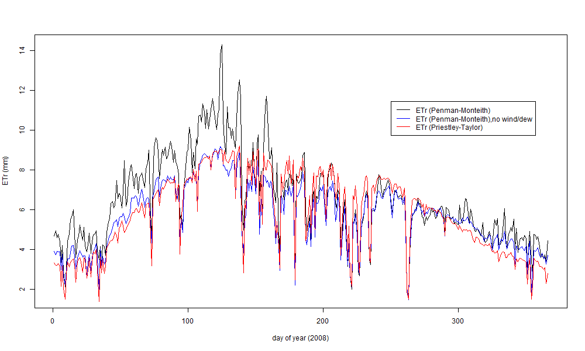

```r
knitr::include_graphics(plotName)
```